# Assignment-3

Tümay Kır

9/13/2020

# Esoph and Youth Survey

## 1.Esoph Analysis

With this analysis, which factors affect (o)esophageal cancer are examined. `esoph` dataset provides some information about these factors such as alcohol consumption, age or tobacco consumption.

Let’s have a look at the data.

```r
str(esoph)
```

```
## 'data.frame':    88 obs. of  5 variables:
##  $ agegp    : Ord.factor w/ 6 levels "25-34"<"35-44"<..: 1 1 1 1 1 1 1 1 1 1 ...
##  $ alcgp    : Ord.factor w/ 4 levels "0-39g/day"<"40-79"<..: 1 1 1 1 2 2 2 2 3 3 ...
##  $ tobgp    : Ord.factor w/ 4 levels "0-9g/day"<"10-19"<..: 1 2 3 4 1 2 3 4 1 2 ...
##  $ ncases   : num  0 0 0 0 0 0 0 0 0 0 ...
##  $ ncontrols: num  40 10 6 5 27 7 4 7 2 1 ...
```

Summary of the dataset is shown.

```r
summary(esoph)
```

```
##    agegp          alcgp         tobgp        ncases         ncontrols
##  25-34:15   0-39g/day:23   0-9g/day:24   Min.   : 0.000   Min.   : 1.00
##  35-44:15   40-79    :23   10-19   :24   1st Qu.: 0.000   1st Qu.: 3.00
##  45-54:16   80-119   :21   20-29   :20   Median : 1.000   Median : 6.00
##  55-64:16   120+     :21   30+     :20   Mean   : 2.273   Mean   :11.08
##  65-74:15                                3rd Qu.: 4.000   3rd Qu.:14.00
##  75+  :11                                Max.   :17.000   Max.   :60.00
```

The dataset include the number of cancer cases. In order to have an insight, observing the `ncases` column by visualizing is beneficial.

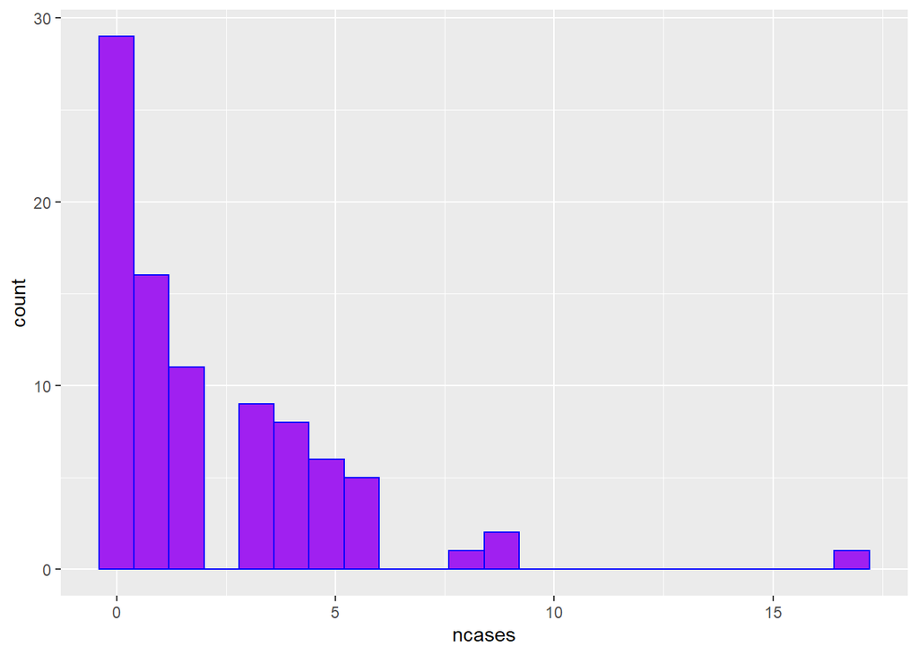

```r
esoph%>%ggplot(aes(x=ncases))+
  geom_histogram(fill="purple",binwidth=0.8,color="blue")
```

After some of the column names are arranged, I assigned numbers to the character columns `Age`,`alcohol` and `tobaccop` by using the function as.numeric(). In this way, a correlation among these factors can be shown.

For instance, age_rank and ncases are positively correlated which makes sense. Although, it is not a strong analysis, it provides an insight.

```r
colnames(esoph)[1]  <- "Age"
colnames(esoph)[2]  <- "alcohol"
colnames(esoph)[3]  <- "tobacco"


esoph["alcohol_rank"]<-as.numeric(esoph$alcohol)
esoph["tobacco_rank"]<-as.numeric(esoph$tobacco)
esoph["age_rank"]<-as.numeric(esoph$Age)
correlation<-cor(esoph[,4:8])
correlation
```

```
##                   ncases   ncontrols alcohol_rank tobacco_rank    age_rank
## ncases        1.00000000  0.31669178   0.07837287  -0.24146185  0.34595015
## ncontrols     0.31669178  1.00000000  -0.47136379  -0.50613974 -0.06116214
## alcohol_rank  0.07837287 -0.47136379   1.00000000  -0.04896281 -0.01521895
## tobacco_rank -0.24146185 -0.50613974  -0.04896281   1.00000000 -0.06780840
## age_rank      0.34595015 -0.06116214  -0.01521895  -0.06780840  1.00000000
```

By grouping the data with respect to `Age`, a percentage of cancer cases is calculated. Thus, the percentage of cases can be seen clearly according to the age groups.

```r
age<-esoph%>%group_by(Age)%>%summarise(total_cases=sum(ncases), total_controls=sum(ncontrols),age_perc=100*(total_cases/total_controls))
```

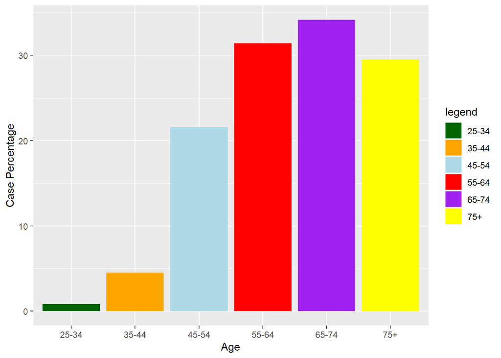

```r
age%>%ggplot(aes(x=Age,y=age_perc,fill=Age))+
  geom_bar(stat="identity",position = "dodge")+
  labs(x="Age",y="Case Percentage")+
  scale_fill_manual(name="legend", values = c("25-34" = "dark green", "35-44" ="orange", "45-54" = "light blue","55-64" = "red","65-74"="purple","75+"="yellow"))
```

Like the previous analysis, by grouping the data with respect to `alcohol`, a percentage of cancer cases is calculated. Thus, the percentage of cases can be seen clearly according to the alcohol consumption groups.

```r
alcohol<-esoph%>%group_by(alcohol)%>%summarise(total_cases=sum(ncases), total_controls=sum(ncontrols),alcohol_perc=100*(total_cases/total_controls))
```

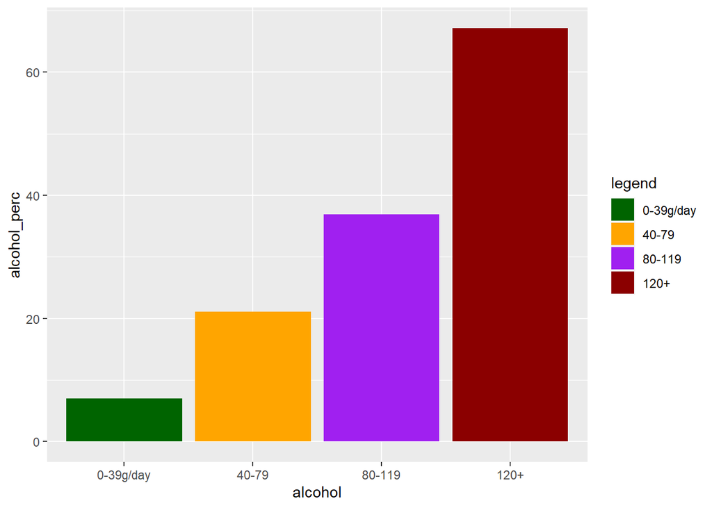

```r
alcohol%>%ggplot(aes(x=alcohol,y=alcohol_perc,fill=alcohol))+
  geom_bar(stat="identity",position = "dodge")+
  scale_fill_manual(name="legend", values = c("0-39g/day" = "dark green", "40-79" ="orange","80-119"="purple","120+"="dark red"))
```

Again by grouping the data with respect to `tobacco`, a percentage of cancer cases is calculated. Thus, the percentage of cases can be seen clearly according to the tobacco consumption groups.

```r
tobacco<-esoph%>%group_by(tobacco)%>%summarise(total_cases=sum(ncases), total_controls=sum(ncontrols),tobacco_perc=100*(total_cases/total_controls))
```

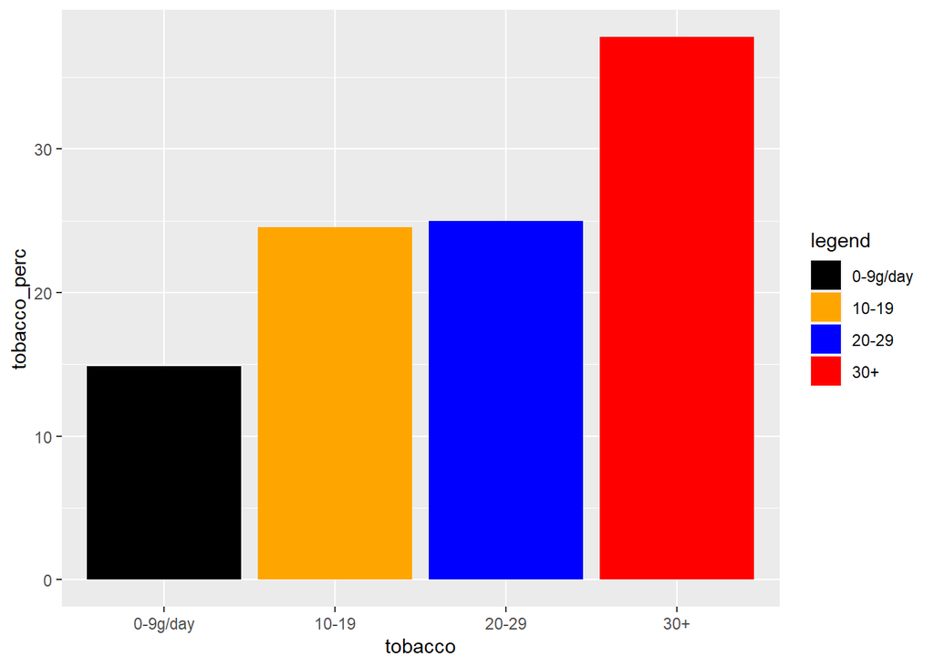

```r
tobacco%>%ggplot(aes(x=tobacco,y=tobacco_perc,fill=tobacco))+
  geom_bar(stat="identity",position = "dodge")+
  scale_fill_manual(name="legend", values = c("0-9g/day" = "black", "10-19" = "orange", "20-29" = "blue","30+" = "red"))
```

Now, the dual series of analysis are shown in the graphs below.

Faceting is used to observe the effects of both tobacco consumption and age groups. More concrete analysis than the previous ones is shown here.

```r
age_tobacco<-esoph %>%group_by(Age,tobacco) %>%
  summarise(total_cases = sum(ncases), total_controls = sum(ncontrols),perc=total_cases/total_controls)
```

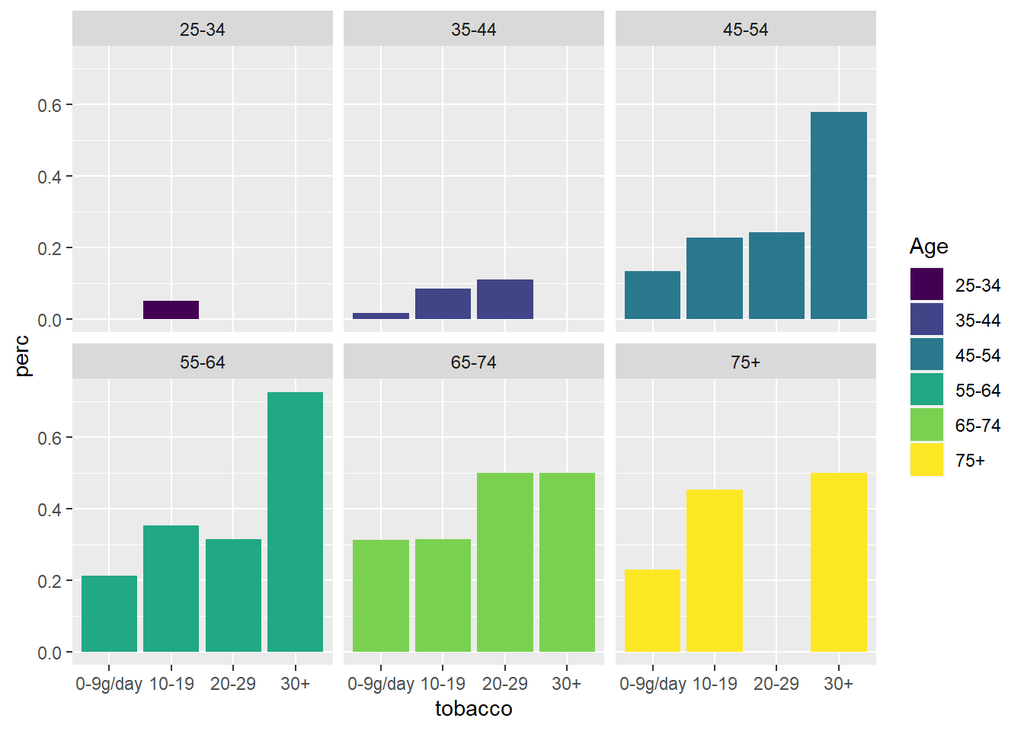

```r
age_tobacco%>%ggplot(aes(x=tobacco,y=perc,fill=Age))+
  geom_bar(stat="identity")+
  facet_wrap(~Age)
```

Again, faceting is used to observe the effects of both alcohol consumption and age groups.

```r
age_alcohol<-esoph %>%group_by(Age,alcohol) %>%
  summarise(total_cases = sum(ncases), total_controls = sum(ncontrols),perc=total_cases/total_controls)
```

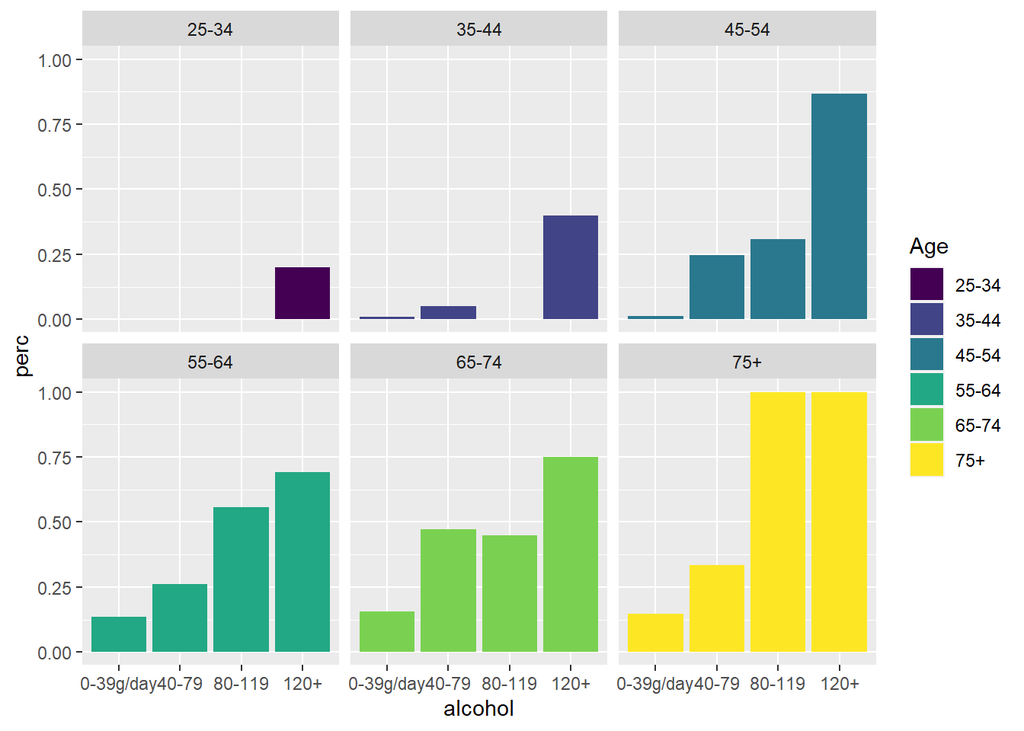

```r
age_alcohol%>%ggplot(aes(x=alcohol,y=perc,fill=Age))+
  geom_bar(stat="identity")+
  facet_wrap(~Age)
```

The final plot related to `esoph` dataset indicates that the mean of `ncontrols` and `ncases` together. Basically, it can be stated that the correlation between the number of controls and cases is positive.

```r
p<-esoph%>%group_by(Age)%>%summarise(mean_case=mean(ncases),mean_controls=mean(ncontrols))
```

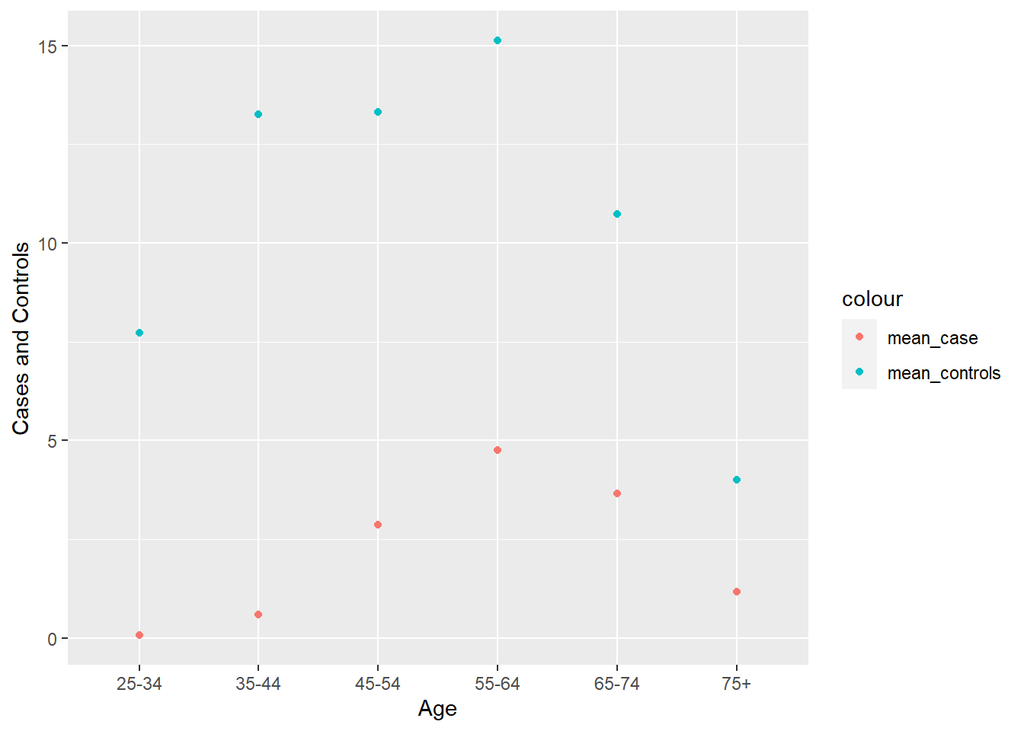

```r
p%>%ggplot() +
  labs(x="Age", y= "Cases and Controls")+
  geom_point(aes(x=Age, y=mean_controls,color="mean_controls"))+
  geom_point(aes(x=Age, y=mean_case,color="mean_case"))
```

### 1.1 Logistic Regression Model of the `esoph` DataSet

In this analysis, the model demonstrates the variables which affect the percentage of canser cases. Since the median value, -0.1171, is close to zero, the model is pretty accurate. Moreover, the result of summary() function indicates that the most significant determinants, which are mainly age and alcohol consumption.

```r
esoph<-esoph%>%mutate(Percentage=ncases/ncontrols)
model<-glm(Percentage ~ Age + alcohol + tobacco,data = esoph, family = quasibinomial)
summary(model)
```

```
##
## Call:
## glm(formula = Percentage ~ Age + alcohol + tobacco, family = quasibinomial,
##     data = esoph)
##
## Deviance Residuals:
##     Min       1Q   Median       3Q      Max
## -1.1643  -0.3252  -0.1171   0.3503   1.8972
##
## Coefficients:
##             Estimate Std. Error t value Pr(>|t|)
## (Intercept) -0.99427    0.17242  -5.767 1.65e-07 ***
## Age.L        3.71812    0.51653   7.198 3.71e-10 ***
## Age.Q       -0.89885    0.42789  -2.101   0.0390 *
## Age.C       -0.03892    0.41409  -0.094   0.9254
## Age^4        0.65217    0.39283   1.660   0.1010
## Age^5       -0.25242    0.33702  -0.749   0.4562
## alcohol.L    2.77885    0.37307   7.449 1.24e-10 ***
## alcohol.Q    0.22427    0.31243   0.718   0.4751
## alcohol.C    0.27787    0.28375   0.979   0.3305
## tobacco.L    0.75343    0.30731   2.452   0.0165 *
## tobacco.Q    0.41824    0.30279   1.381   0.1712
## tobacco.C    0.40745    0.30274   1.346   0.1823
## ---
## Signif. codes:  0 '***' 0.001 '**' 0.01 '*' 0.05 '.' 0.1 ' ' 1
##
## (Dispersion parameter for quasibinomial family taken to be 0.2619169)
##
##     Null deviance: 61.609  on 87  degrees of freedom
## Residual deviance: 21.194  on 76  degrees of freedom
## AIC: NA
##
## Number of Fisher Scoring iterations: 6
```

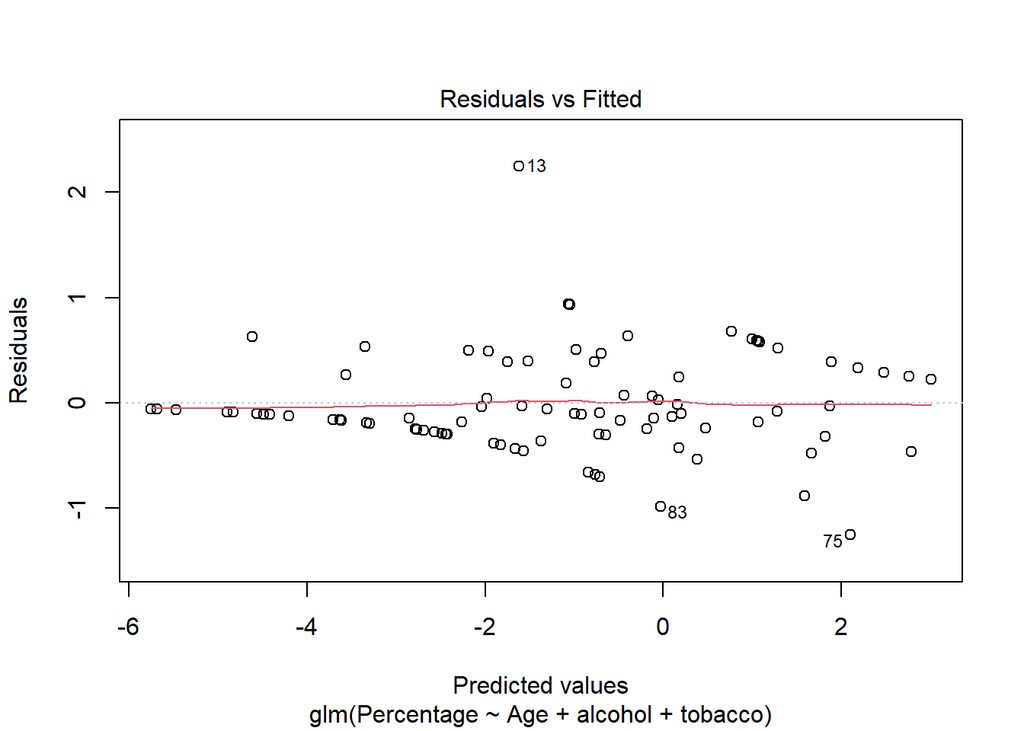

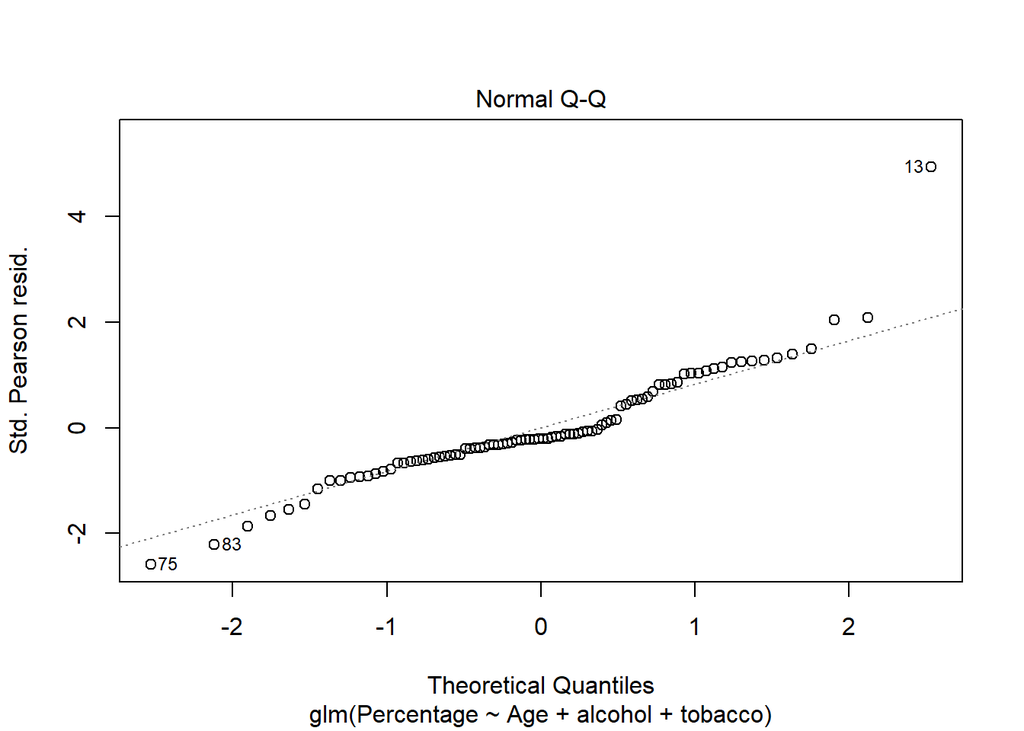

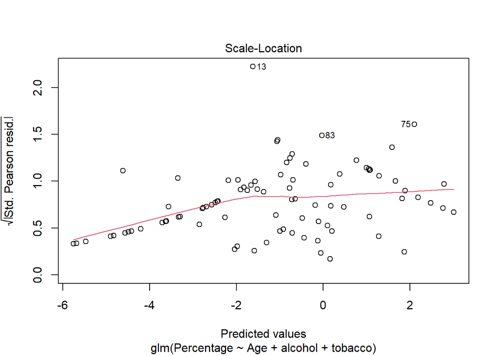

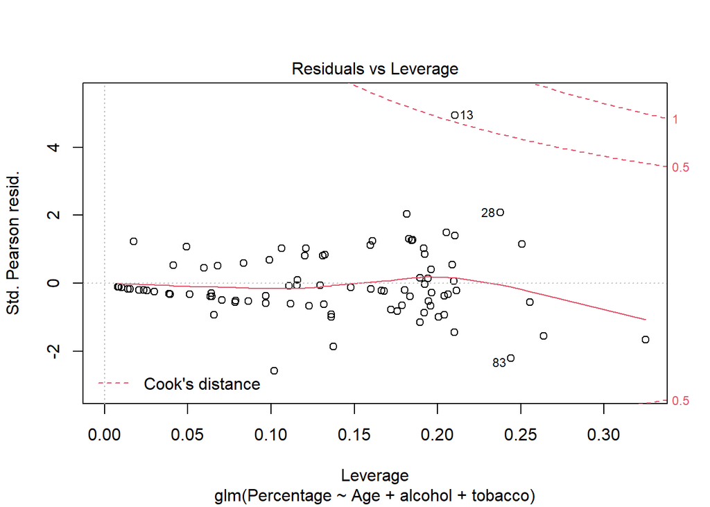

```r
plot(model)
```

```r
anova(model)
```

```
## Analysis of Deviance Table
##
## Model: quasibinomial, link: logit
##
## Response: Percentage
##
## Terms added sequentially (first to last)
##
##
##         Df Deviance Resid. Df Resid. Dev
## NULL                       87     61.609
## Age      5  17.5904        82     44.019
## alcohol  3  20.3579        79     23.661
## tobacco  3   2.4663        76     21.194
```

## 2.Young People Survey Analysis

In this part of the assignment, the Young People Survey’s Hobbies & Interests category answers are examined. In order to conduct this analysis, PCA model and Multidimensional Scaling Methods are used.

```r
data<-read.csv("C:/Users/tumay/Desktop/Young_People_Survey.csv")
```

### 2.1 PCA Analysis

PCA test is applied to `filtered_data`, which consists of the numeric columns from 15 to 67.

```r
filtered_data<-data%>%filter(complete.cases(.))
filtered_data<-filtered_data[,15:67]

data_pca <- princomp(filtered_data,cor=T)
summary(data_pca,loadings=TRUE)
```

```
## Importance of components:
##                           Comp.1     Comp.2     Comp.3     Comp.4     Comp.5
## Standard deviation     2.3231451 2.19050893 1.75118997 1.64587757 1.44032037
## Proportion of Variance 0.1018302 0.09053452 0.05786163 0.05111157 0.03914194
## Cumulative Proportion  0.1018302 0.19236477 0.25022639 0.30133796 0.34047990
##                            Comp.6    Comp.7     Comp.8     Comp.9    Comp.10
## Standard deviation     1.34058286 1.2865296 1.27125477 1.22491574 1.14052531
## Proportion of Variance 0.03390872 0.0312294 0.03049224 0.02830978 0.02454336
## Cumulative Proportion  0.37438862 0.4056180 0.43611027 0.46442005 0.48896341
##                           Comp.11    Comp.12    Comp.13    Comp.14    Comp.15
## Standard deviation     1.13707146 1.06989861 1.06366720 1.04970230 1.00695570
## Proportion of Variance 0.02439493 0.02159779 0.02134694 0.02079009 0.01913132
## Cumulative Proportion  0.51335834 0.53495614 0.55630308 0.57709317 0.59622449
##                           Comp.16    Comp.17    Comp.18    Comp.19    Comp.20
## Standard deviation     0.98410315 0.97276291 0.96465840 0.94146093 0.93271558
## Proportion of Variance 0.01827281 0.01785411 0.01755785 0.01672356 0.01641431
## Cumulative Proportion  0.61449730 0.63235141 0.64990925 0.66663281 0.68304712
##                           Comp.21    Comp.22    Comp.23    Comp.24    Comp.25
## Standard deviation     0.90333350 0.90135656 0.89663043 0.87648198 0.85864585
## Proportion of Variance 0.01539644 0.01532913 0.01516879 0.01449473 0.01391081
## Cumulative Proportion  0.69844356 0.71377269 0.72894148 0.74343621 0.75734702
##                           Comp.26    Comp.27    Comp.28    Comp.29   Comp.30
## Standard deviation     0.84343260 0.83941708 0.81933601 0.80346937 0.8001699
## Proportion of Variance 0.01342224 0.01329474 0.01266625 0.01218043 0.0120806
## Cumulative Proportion  0.77076926 0.78406399 0.79673025 0.80891068 0.8209913
##                           Comp.31    Comp.32    Comp.33    Comp.34    Comp.35
## Standard deviation     0.77896791 0.76768011 0.75790252 0.74812862 0.72925097
## Proportion of Variance 0.01144889 0.01111949 0.01083804 0.01056031 0.01003409
## Cumulative Proportion  0.83244017 0.84355966 0.85439770 0.86495801 0.87499210
##                            Comp.36     Comp.37     Comp.38     Comp.39
## Standard deviation     0.716594918 0.694077945 0.685334696 0.671012000
## Proportion of Variance 0.009688835 0.009089513 0.008861956 0.008495417
## Cumulative Proportion  0.884680938 0.893770451 0.902632406 0.911127823
##                            Comp.40     Comp.41     Comp.42     Comp.43
## Standard deviation     0.662043197 0.649621865 0.646638873 0.629174972
## Proportion of Variance 0.008269834 0.007962426 0.007889469 0.007469078
## Cumulative Proportion  0.919397657 0.927360083 0.935249552 0.942718630
##                            Comp.44     Comp.45     Comp.46     Comp.47
## Standard deviation     0.616960474 0.605135014 0.597866716 0.574830062
## Proportion of Variance 0.007181891 0.006909215 0.006744238 0.006234521
```

[output cut: 428 more lines]

```
## Writing                        -0.150
## Passive.sport
## Active.sport
## Gardening
## Celebrities
## Shopping                       -0.159
## Science.and.technology          0.157
## Theatre                        -0.281
## Fun.with.friends
## Adrenaline.sports
## Pets
## Flying
## Storm                           0.122
## Darkness
## Heights
```

The plot method returns a plot of the variances (y-axis) associated with the components (x-axis).In this case, it can be seen that the first 15 responses explain 60% of the variability of the data.

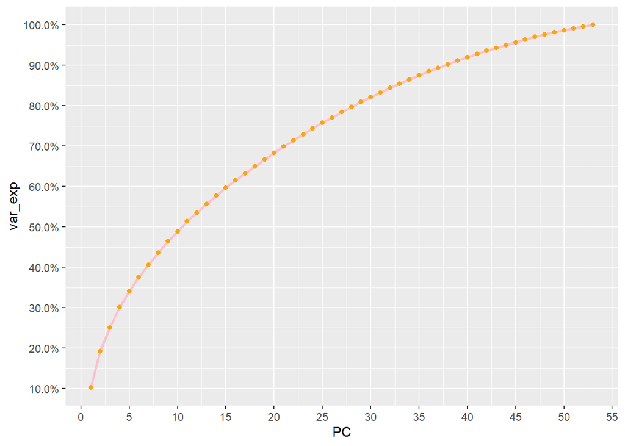

```r
ggplot(data=data.frame(PC=1:length(data_pca$sdev),var_exp=cumsum(data_pca$sdev^2/sum(data_pca$sdev^2))),
       aes(x=PC,y=var_exp)) + geom_line(color="pink",size=1) + geom_point(color="orange") + scale_y_continuous(labels = scales::percent,breaks=seq(0,1,length.out=11)) + scale_x_continuous(breaks=seq(0,135,by=5))
```

### 2.2 Multidimensional Scaling

In this part, Multidimensional Scaling method is conducted on the data. This method shows the level of similarity among the selected components.

```r
set.seed(250)

yr_dist<- 1 - cor(filtered_data)
yr_mds <- cmdscale(yr_dist,k=2)
colnames(yr_mds) <- c("x","y")
print(yr_mds)
```

```
##                                   x           y
## Rock.n.roll             0.022158038  0.18727673
## Alternative             0.037350001  0.32684644
## Latino                  0.291933189 -0.04142127
## Techno..Trance         -0.175790568 -0.21637751
## Opera                   0.057311202  0.39829458
## Movies                 -0.041329409 -0.17346841
## Horror                 -0.287533255 -0.23395821
## Thriller               -0.359768936 -0.17433690
## Comedy                 -0.006156985 -0.42318887
## Romantic                0.457515707 -0.30517323
## Sci.fi                 -0.429642915  0.02926328
## War                    -0.454140138  0.07351693
## Fantasy.Fairy.tales     0.369032835 -0.09689877
## Animated                0.239413785 -0.05970655
## Documentary            -0.195767546  0.32178408
## Western                -0.402641395  0.14016846
## Action                 -0.500882498 -0.16081672
## History                -0.121111940  0.32884122
## Psychology              0.167090290  0.20210675
## Politics               -0.259850792  0.12019679
## Mathematics            -0.335582562  0.10371171
## Physics                -0.377235281  0.26705400
## Internet               -0.302631033 -0.31860761
## PC                     -0.554941896 -0.08886546
## Economy.Management     -0.180673368 -0.26016819
## Biology                 0.222607052  0.20224995
## Chemistry               0.080031491  0.20028131
## Reading                 0.428366618  0.31240462
## Geography              -0.136001181  0.18475627
## Foreign.languages       0.204744658  0.09545044
## Medicine                0.155973512  0.21900177
## Law                    -0.075205375 -0.05002566
## Cars                   -0.503879652 -0.26197468
## Art.exhibitions         0.316526960  0.29360256
## Religion                0.107533839  0.30803021
## Countryside..outdoors   0.163118253  0.14822966
## Dancing                 0.379408634 -0.03316559
## Musical.instruments     0.141000321  0.24109634
## Writing                 0.195751273  0.24211614
## Passive.sport          -0.193529692 -0.24546252
## Active.sport           -0.175758453 -0.09578911
## Gardening               0.234802948  0.04932904
## Celebrities             0.242535730 -0.49954288
## Shopping                0.396809275 -0.43776053
## Science.and.technology -0.441515213  0.20671263
## Theatre                 0.404002016  0.25853018
## Fun.with.friends        0.051592761 -0.19758704
## Adrenaline.sports      -0.283025629 -0.02684918
## Pets                    0.178489393 -0.18624603
## Flying                  0.226087584 -0.20005609
## Storm                   0.423599917 -0.26672732
## Darkness                0.436901908 -0.22801375
## Heights                 0.162906520 -0.17866405
```

Selected columns are visualized below.

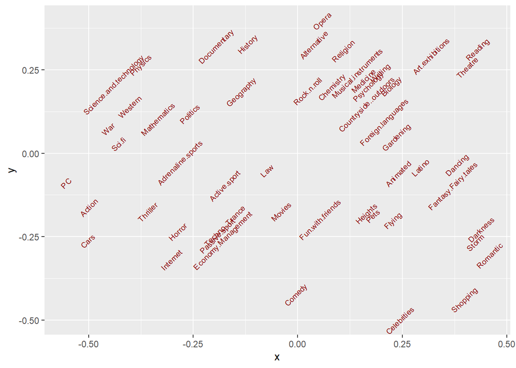

```r
ggplot(data.frame(yr_mds),aes(x=x,y=y)) + geom_text(color="dark red",label=rownames(yr_mds),angle=45,size=2.6)
```